# projectphase2

### Course Project (Phase 2)

In Phase 2 of the project, you will build predictive models and assess their performance.

You should use the results of your Phase 1 work for data cleaning and preparation.

Begin by loading packages. You may not need the functionality provided by all of these packages.

Read in the data with the following code:

```r
churn = read_csv("Churn_Modelling.csv")
```

The variables in the dataset are:  
* Row Number - Can be deleted  
* CustomerId - Unique identifier for each customer  
* Surname - Customer’s last name  
* CreditScore - Customer’s credit score (higher is better)  
* Geography - Customer’s country  
* Gender - Customer’s gender  
* Age - Customer’s age  
* Tenure - Number of years that the customer has been with the bank  
* Balance - Customer’s bank balance  
* NumOfProducts - The number of bank products that the customer is using  
* HasCrCard - Indicate whether the customer has (1) a credit card with the bank or (0) not  
* IsActiveMember - Indicates the customer is (1) an active member of the bank or (0) not  
* EstimatedSalary - The estimated salary of the customer  
* Exited - An indicator that shows if the customer closed their account with the bank (1) or (0) not (This is the response variable)

Run your code from Phase 1 to clean and prepare the data. This code should complete the following tasks:

## Delete the RowNumber, CustomerId, and Surname columns (NOTE: The MASS package has been loaded so you will need to be careful if you choose to use the select function)

```r
churn = churn %>% dplyr::select(-RowNumber, -CustomerId, -Surname)
str(churn)
```

```
tibble [10,000 × 11] (S3: tbl_df/tbl/data.frame)
 $ CreditScore    : num [1:10000] 619 608 502 699 850 645 822 376 501 684 ...
 $ Geography      : chr [1:10000] "France" "Spain" "France" "France" ...
 $ Gender         : chr [1:10000] "Female" "Female" "Female" "Female" ...
 $ Age            : num [1:10000] 42 41 42 39 43 44 50 29 44 27 ...
 $ Tenure         : num [1:10000] 2 1 8 1 2 8 7 4 4 2 ...
 $ Balance        : num [1:10000] 0 83808 159661 0 125511 ...
 $ NumOfProducts  : num [1:10000] 1 1 3 2 1 2 2 4 2 1 ...
 $ HasCrCard      : num [1:10000] 1 0 1 0 1 1 1 1 0 1 ...
 $ IsActiveMember : num [1:10000] 1 1 0 0 1 0 1 0 1 1 ...
 $ EstimatedSalary: num [1:10000] 101349 112543 113932 93827 79084 ...
 $ Exited         : num [1:10000] 1 0 1 0 0 1 0 1 0 0 ...
```

## Convert the Geography, Gender, HasCrCard, IsActiveMember, and Exited columns to factors

```r
churn = churn %>% mutate (Geography = as_factor(Geography), Gender = as_factor(Gender), HasCrCard = as_factor(HasCrCard), IsActiveMember = as_factor(IsActiveMember), Exited = as_factor(Exited))
str(churn)
```

```
tibble [10,000 × 11] (S3: tbl_df/tbl/data.frame)
 $ CreditScore    : num [1:10000] 619 608 502 699 850 645 822 376 501 684 ...
 $ Geography      : Factor w/ 3 levels "France","Spain",..: 1 2 1 1 2 2 1 3 1 1 ...
 $ Gender         : Factor w/ 2 levels "Female","Male": 1 1 1 1 1 2 2 1 2 2 ...
 $ Age            : num [1:10000] 42 41 42 39 43 44 50 29 44 27 ...
 $ Tenure         : num [1:10000] 2 1 8 1 2 8 7 4 4 2 ...
 $ Balance        : num [1:10000] 0 83808 159661 0 125511 ...
 $ NumOfProducts  : num [1:10000] 1 1 3 2 1 2 2 4 2 1 ...
 $ HasCrCard      : Factor w/ 2 levels "0","1": 2 1 2 1 2 2 2 2 1 2 ...
 $ IsActiveMember : Factor w/ 2 levels "0","1": 2 2 1 1 2 1 2 1 2 2 ...
 $ EstimatedSalary: num [1:10000] 101349 112543 113932 93827 79084 ...
 $ Exited         : Factor w/ 2 levels "0","1": 2 1 2 1 1 2 1 2 1 1 ...
```

## Rename the levels of the HasCrCard, IsActiveMember, and Exited columns from 0 and 1 to No and Yes (You may use more descriptive namings if you prefer)

```r
churn = churn %>% mutate(
  HasCrCard = fct_recode(HasCrCard, "No" = "0", "Yes" = "1") ,
  IsActiveMember = fct_recode(IsActiveMember, "No" = "0", "Yes" = "1") ,
  Exited = fct_recode(Exited, "No" = "0", "Yes" = "1")
)

str(churn)
```

```
tibble [10,000 × 11] (S3: tbl_df/tbl/data.frame)
 $ CreditScore    : num [1:10000] 619 608 502 699 850 645 822 376 501 684 ...
 $ Geography      : Factor w/ 3 levels "France","Spain",..: 1 2 1 1 2 2 1 3 1 1 ...
 $ Gender         : Factor w/ 2 levels "Female","Male": 1 1 1 1 1 2 2 1 2 2 ...
 $ Age            : num [1:10000] 42 41 42 39 43 44 50 29 44 27 ...
 $ Tenure         : num [1:10000] 2 1 8 1 2 8 7 4 4 2 ...
 $ Balance        : num [1:10000] 0 83808 159661 0 125511 ...
 $ NumOfProducts  : num [1:10000] 1 1 3 2 1 2 2 4 2 1 ...
 $ HasCrCard      : Factor w/ 2 levels "No","Yes": 2 1 2 1 2 2 2 2 1 2 ...
 $ IsActiveMember : Factor w/ 2 levels "No","Yes": 2 2 1 1 2 1 2 1 2 2 ...
 $ EstimatedSalary: num [1:10000] 101349 112543 113932 93827 79084 ...
 $ Exited         : Factor w/ 2 levels "No","Yes": 2 1 2 1 1 2 1 2 1 1 ...
```

```r
summary(churn)
```

```
  CreditScore      Geography       Gender          Age            Tenure
 Min.   :350.0   France :5014   Female:4543   Min.   :18.00   Min.   : 0.000
 1st Qu.:584.0   Spain  :2477   Male  :5457   1st Qu.:32.00   1st Qu.: 3.000
 Median :652.0   Germany:2509                 Median :37.00   Median : 5.000
 Mean   :650.5                                Mean   :38.92   Mean   : 5.013
 3rd Qu.:718.0                                3rd Qu.:44.00   3rd Qu.: 7.000
 Max.   :850.0                                Max.   :92.00   Max.   :10.000
    Balance       NumOfProducts  HasCrCard  IsActiveMember EstimatedSalary
 Min.   :     0   Min.   :1.00   No :2945   No :4849       Min.   :    11.58
 1st Qu.:     0   1st Qu.:1.00   Yes:7055   Yes:5151       1st Qu.: 51002.11
 Median : 97199   Median :1.00                             Median :100193.91
 Mean   : 76486   Mean   :1.53                             Mean   :100090.24
 3rd Qu.:127644   3rd Qu.:2.00                             3rd Qu.:149388.25
 Max.   :250898   Max.   :4.00                             Max.   :199992.48
 Exited
 No :7963
 Yes:2037
```

## Split the data into training and testing sets (Use a 70/30 training/testing split with a random number seed of 1234)

```r
set.seed(1234)
churn_split = initial_split(churn, prop = 0.7,)
train = training(churn_split)
test = testing(churn_split)
```

For Phase 2 work, complete the following tasks:

## Compute the accuracy of a naive model on the training set

```r
train_naive_accuarcy_neg = max(table(train$Exited)) / nrow(train)
print(train_naive_accuarcy_neg)
```

```
[1] 0.7925714
```

```r
train_naive_accuracy_pos = sum(train$Exited == "Yes") / nrow(train)
print(train_naive_accuracy_pos)
```

```
[1] 0.2074286
```

```r
test_accuracy = max(table(test$Exited)) / nrow(test)
print(test_accuracy)
```

```
[1] 0.805
```

```r
test_accuracy = sum(test$Exited == "Yes") / nrow(test)
print(test_accuracy)
```

```
[1] 0.195
```

## Build the best logistic regression model that you can (including selection of an appropriate threshold)

```r
logreg_model1 =
  logistic_reg() %>%
  set_engine("glm")

logreg_recipe1 = recipe(Exited ~. , data = train) %>%
  step_dummy(all_nominal(), -all_outcomes())

logreg_wf1 = workflow() %>%
  add_recipe(logreg_recipe1) %>%
  add_model(logreg_model1)

logreg_fit1 = fit(logreg_wf1,train)

tidy(logreg_fit1)
```

```
# A tibble: 12 × 5
   term                   estimate   std.error statistic   p.value
   <chr>                     <dbl>       <dbl>     <dbl>     <dbl>
 1 (Intercept)        -3.40        0.291         -11.7   1.53e- 31
 2 CreditScore        -0.000599    0.000336       -1.78  7.45e-  2
 3 Age                 0.0725      0.00307        23.6   5.77e-123
 4 Tenure             -0.0158      0.0111         -1.42  1.55e-  1
 5 Balance             0.00000278  0.000000611     4.55  5.25e-  6
 6 NumOfProducts      -0.146       0.0562         -2.59  9.54e-  3
 7 EstimatedSalary     0.000000211 0.000000564     0.374 7.08e-  1
 8 Geography_Spain     0.0586      0.0845          0.694 4.88e-  1
 9 Geography_Germany   0.852       0.0801         10.6   1.98e- 26
10 Gender_Male        -0.518       0.0650         -7.97  1.57e- 15
11 HasCrCard_Yes       0.0104      0.0712          0.146 8.84e-  1
12 IsActiveMember_Yes -1.06        0.0684        -15.5   2.11e- 54
```

```r
glance(logreg_fit1)
```

```
# A tibble: 1 × 8
  null.deviance df.null logLik   AIC   BIC deviance df.residual  nobs
          <dbl>   <int>  <dbl> <dbl> <dbl>    <dbl>       <int> <int>
1         7147.    6999 -3009. 6042. 6124.    6018.        6988  7000
```

```r
predicttrain = predict(logreg_fit1, train, type="prob") #Make predictions on train set first
head(predicttrain)
```

```
# A tibble: 6 × 2
  .pred_No .pred_Yes
     <dbl>     <dbl>
1    0.963    0.0370
2    0.892    0.108
3    0.754    0.246
4    0.905    0.0948
5    0.852    0.148
6    0.748    0.252
```

```r
predicttrain = predicttrain[2]
head(predicttrain)
```

```
# A tibble: 6 × 1
  .pred_Yes
      <dbl>
1    0.0370
2    0.108
3    0.246
4    0.0948
5    0.148
6    0.252
```

```r
ROCRpred = prediction(predicttrain, train$Exited)
```

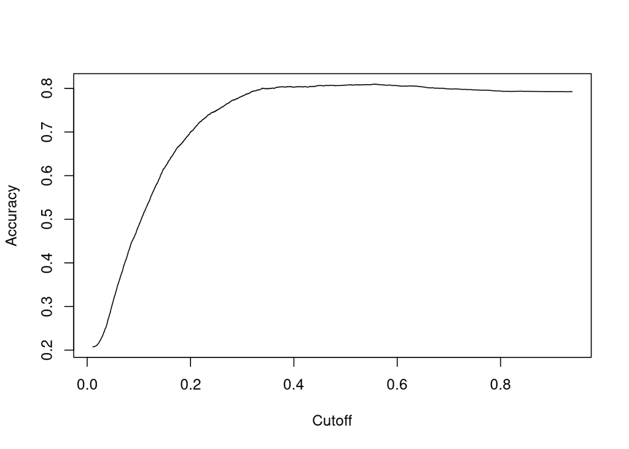

```r
acc.perf = performance(ROCRpred, measure = "acc")
plot(acc.perf)
```

```r
ind = which.max( slot(acc.perf, "y.values")[[1]] )
acc = slot(acc.perf, "y.values")[[1]][ind]
cutoff = slot(acc.perf, "x.values")[[1]][ind]
print(c(accuracy= acc, cutoff = cutoff))
```

```
 accuracy    cutoff
0.8097143 0.5587024
```

```r
predicttest = predict(logreg_fit1, test, type="prob")[2]
t2 = table(test$Exited, predicttest > 0.5587024)
t2
```

```
      FALSE TRUE
  No   2355   60
  Yes   480  105
```

```r
#Accuracy
(t2[1,1]+t2[2,2])/(nrow(test))
```

```
[1] 0.82
```

## Build the best classification tree that you can

```r
set.seed(234)
folds = vfold_cv(train, v = 5)
```

```r
churn_recipe = recipe(Exited ~., train) %>%
  step_dummy(all_nominal(),-all_outcomes())

tree_model = decision_tree(cost_complexity = tune()) %>%
  set_engine("rpart", model = TRUE) %>% #don't forget the model = TRUE flag
  set_mode("classification")

tree_grid = expand.grid(cost_complexity = seq(0.001,0.01,by=0.001))

churn_wflow =
  workflow() %>%
  add_model(tree_model) %>%
  add_recipe(churn_recipe)

tree_res =
  churn_wflow %>%
  tune_grid(
    resamples = folds,
    grid = tree_grid
    )

tree_res
```

```
# Tuning results
# 5-fold cross-validation
# A tibble: 5 × 4
  splits              id    .metrics          .notes
  <list>              <chr> <list>            <list>
1 <split [5600/1400]> Fold1 <tibble [30 × 5]> <tibble [0 × 3]>
2 <split [5600/1400]> Fold2 <tibble [30 × 5]> <tibble [0 × 3]>
3 <split [5600/1400]> Fold3 <tibble [30 × 5]> <tibble [0 × 3]>
4 <split [5600/1400]> Fold4 <tibble [30 × 5]> <tibble [0 × 3]>
5 <split [5600/1400]> Fold5 <tibble [30 × 5]> <tibble [0 × 3]>
```

```r
best_tree = tree_res %>%
  select_best(metric="accuracy")

best_tree
```

```
# A tibble: 1 × 2
  cost_complexity .config
            <dbl> <chr>
1           0.003 Preprocessor1_Model03
```

```r
final_wf =
  churn_wflow %>%
  finalize_workflow(best_tree)
```

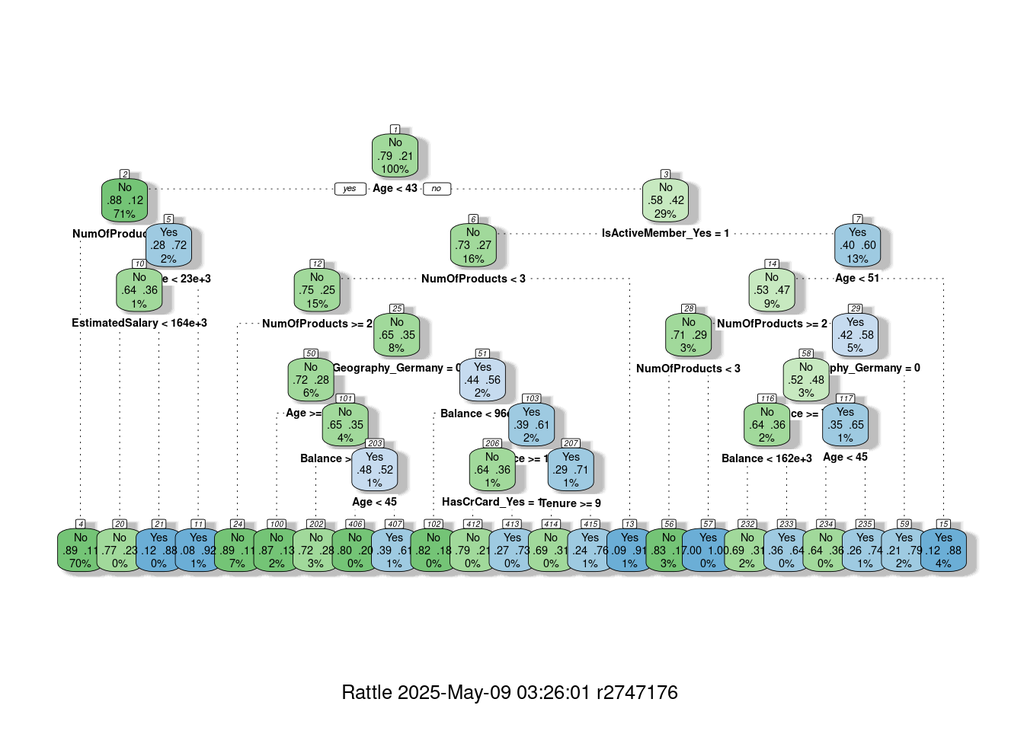

```r
final_fit2 = fit(final_wf, train)

tree = final_fit2 %>%
  pull_workflow_fit() %>%
  pluck("fit")
fancyRpartPlot(tree, tweak = 1.5)
```

```r
treepred = predict(final_fit2, train, type = "class")
head(treepred)
```

```
# A tibble: 6 × 1
  .pred_class
  <fct>
1 No
2 No
3 No
4 No
5 No
6 No
```

```r
confusionMatrix(treepred$.pred_class, train$Exited, positive="Yes") #predictions first then actual
```

```
Confusion Matrix and Statistics

          Reference
Prediction   No  Yes
       No  5396  755
       Yes  152  697

               Accuracy : 0.8704
                 95% CI : (0.8623, 0.8782)
    No Information Rate : 0.7926
    P-Value [Acc > NIR] : < 2.2e-16

                  Kappa : 0.5346

 Mcnemar's Test P-Value : < 2.2e-16

            Sensitivity : 0.48003
            Specificity : 0.97260
         Pos Pred Value : 0.82097
         Neg Pred Value : 0.87726
             Prevalence : 0.20743
         Detection Rate : 0.09957
   Detection Prevalence : 0.12129
      Balanced Accuracy : 0.72632

       'Positive' Class : Yes
```

```r
treepred_test = predict(final_fit2, test, type = "class")
head(treepred_test)
```

```
# A tibble: 6 × 1
  .pred_class
  <fct>
1 No
2 No
3 No
4 No
5 Yes
6 No
```

```r
confusionMatrix(treepred_test$.pred_class, test$Exited, positive="Yes") #predictions first then actual
```

```
Confusion Matrix and Statistics

          Reference
Prediction   No  Yes
       No  2326  318
       Yes   89  267

               Accuracy : 0.8643
                 95% CI : (0.8516, 0.8764)
    No Information Rate : 0.805
    P-Value [Acc > NIR] : < 2.2e-16

                  Kappa : 0.4926

 Mcnemar's Test P-Value : < 2.2e-16

            Sensitivity : 0.4564
            Specificity : 0.9631
         Pos Pred Value : 0.7500
         Neg Pred Value : 0.8797
             Prevalence : 0.1950
         Detection Rate : 0.0890
   Detection Prevalence : 0.1187
      Balanced Accuracy : 0.7098

       'Positive' Class : Yes
```

## Build the best random forest that you can

```r
set.seed(123)
rf_folds = vfold_cv(train, v = 5)
# we do three or ten folds when the dataset is too big or too small
```

```r
churn_recipe2 = recipe(Exited ~., train) %>%
  step_dummy(all_nominal(), -all_outcomes())

rf_model2 = rand_forest(mtry = tune(), min_n = tune(), trees = 300) %>%
  #ranger lets us tune mtr, min_n, and trees
  #tuning mtry and min_n parameters
  #set trees to default of 500
  set_engine("ranger", importance = "permutation") %>% #added importance metric
  set_mode("classification")




churn_wflow2 =
  workflow() %>%
  add_model(rf_model2) %>%
  add_recipe(churn_recipe2)

set.seed(123)
rf_res2 = tune_grid(
  churn_wflow2,
  resamples = rf_folds,
  grid = 50 #try 50 different combinations of the random forest tuning parameters
)
```

```
i Creating pre-processing data to finalize unknown parameter: mtry
```

```r
best_rf = select_best(rf_res2, metric= "accuracy")

final_rf = finalize_workflow(
  churn_wflow2,
  best_rf
)

final_rf
```

```
══ Workflow ════════════════════════════════════════════════════════════════════
Preprocessor: Recipe
Model: rand_forest()

── Preprocessor ────────────────────────────────────────────────────────────────
1 Recipe Step

• step_dummy()

── Model ───────────────────────────────────────────────────────────────────────
Random Forest Model Specification (classification)

Main Arguments:
  mtry = 5
  trees = 300
  min_n = 13

Engine-Specific Arguments:
  importance = permutation

Computational engine: ranger
```

```r
#fit the finalized workflow to our training data
final_rf_fit = fit(final_rf, train)
```

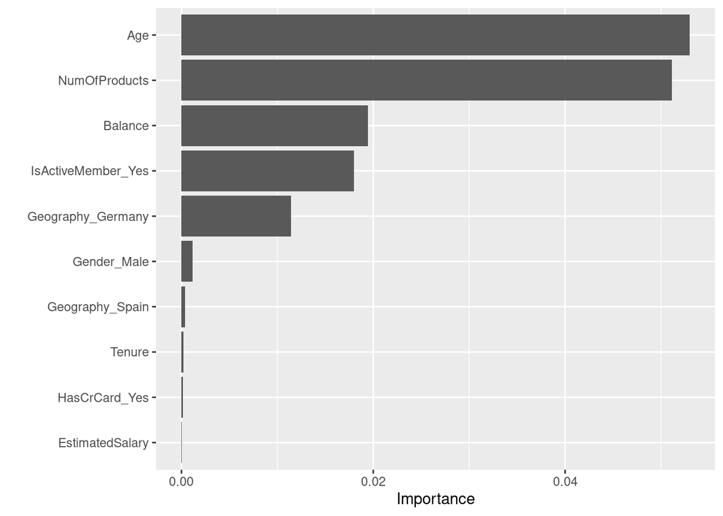

```r
final_rf_fit %>% extract_fit_parsnip() %>% vip()
```

```r
trainpredrf = predict(final_rf_fit, train)
confusionMatrix(trainpredrf$.pred_class, train$Exited,
                positive = "Yes")
```

```
Confusion Matrix and Statistics

          Reference
Prediction   No  Yes
       No  5496  366
       Yes   52 1086

               Accuracy : 0.9403
                 95% CI : (0.9345, 0.9457)
    No Information Rate : 0.7926
    P-Value [Acc > NIR] : < 2.2e-16

                  Kappa : 0.8026

 Mcnemar's Test P-Value : < 2.2e-16

            Sensitivity : 0.7479
            Specificity : 0.9906
         Pos Pred Value : 0.9543
         Neg Pred Value : 0.9376
             Prevalence : 0.2074
         Detection Rate : 0.1551
   Detection Prevalence : 0.1626
      Balanced Accuracy : 0.8693

       'Positive' Class : Yes
```

```r
testpredrf = predict(final_rf_fit, test)
confusionMatrix(testpredrf$.pred_class, test$Exited,
                positive = "Yes")
```

```
Confusion Matrix and Statistics

          Reference
Prediction   No  Yes
       No  2310  291
       Yes  105  294

               Accuracy : 0.868
                 95% CI : (0.8554, 0.8799)
    No Information Rate : 0.805
    P-Value [Acc > NIR] : < 2.2e-16

                  Kappa : 0.522

 Mcnemar's Test P-Value : < 2.2e-16

            Sensitivity : 0.5026
            Specificity : 0.9565
         Pos Pred Value : 0.7368
         Neg Pred Value : 0.8881
             Prevalence : 0.1950
         Detection Rate : 0.0980
   Detection Prevalence : 0.1330
      Balanced Accuracy : 0.7295

       'Positive' Class : Yes
```

- Provide a summary of your models’ performance versus the naive model on the training set and on the testing set
- Discuss the practical implications of your models, including a discussion on accuracy versus sensitivity

As in Phase 1, your primary deliverable is a six-slide PowerPoint presentation. This presentation should summarize your results. Recall that your audience for this deliverable is non-technical. Please focus on the practical use of your models. Please do not include any R code in your slides. You will also upload your rendered R work to Canvas.